# Risk Factor Analysis

## Outcome Variable

**Outcome Variable:** haz

## Predictor Variables

**Intervention Variable:** nrooms

**Adjustment Set:**

- arm
- sex
- W_mage
- meducyrs
- feducyrs
- hhwealth_quart
- hfoodsec
- W_mhtcm
- W_mwtkg
- W_mbmi
- W_nchldlt5
- W_parity
- impfloor
- impsan
- safeh20
- delta_W_mage
- delta_meducyrs
- delta_feducyrs
- delta_hhwealth_quart
- delta_hfoodsec
- delta_W_mhtcm
- delta_W_mwtkg
- delta_W_mbmi
- delta_W_nchldlt5
- delta_W_parity
- delta_impfloor
- delta_impsan
- delta_safeh20

## Stratifying Variables

The analysis was stratified on these variable(s):

- agecat
- studyid
- country

## Data Summary

| agecat | studyid | country | nrooms | n_cell | n |
| --- | --- | --- | --- | --- | --- |
| Birth | ki0047075b-MAL-ED | BANGLADESH | 4+ | 12 | 213 |
| Birth | ki0047075b-MAL-ED | BANGLADESH | 1 | 130 | 213 |
| Birth | ki0047075b-MAL-ED | BANGLADESH | 2 | 46 | 213 |
| Birth | ki0047075b-MAL-ED | BANGLADESH | 3 | 25 | 213 |
| Birth | ki0047075b-MAL-ED | BRAZIL | 4+ | 30 | 60 |
| Birth | ki0047075b-MAL-ED | BRAZIL | 1 | 0 | 60 |
| Birth | ki0047075b-MAL-ED | BRAZIL | 2 | 10 | 60 |
| Birth | ki0047075b-MAL-ED | BRAZIL | 3 | 20 | 60 |
| Birth | ki0047075b-MAL-ED | INDIA | 4+ | 2 | 41 |
| Birth | ki0047075b-MAL-ED | INDIA | 1 | 18 | 41 |
| Birth | ki0047075b-MAL-ED | INDIA | 2 | 17 | 41 |
| Birth | ki0047075b-MAL-ED | INDIA | 3 | 4 | 41 |
| Birth | ki0047075b-MAL-ED | NEPAL | 4+ | 15 | 26 |
| Birth | ki0047075b-MAL-ED | NEPAL | 1 | 7 | 26 |
| Birth | ki0047075b-MAL-ED | NEPAL | 2 | 2 | 26 |
| Birth | ki0047075b-MAL-ED | NEPAL | 3 | 2 | 26 |
| Birth | ki0047075b-MAL-ED | PERU | 4+ | 107 | 215 |
| Birth | ki0047075b-MAL-ED | PERU | 1 | 13 | 215 |
| Birth | ki0047075b-MAL-ED | PERU | 2 | 45 | 215 |
| Birth | ki0047075b-MAL-ED | PERU | 3 | 50 | 215 |
| Birth | ki0047075b-MAL-ED | SOUTH AFRICA | 4+ | 67 | 96 |
| Birth | ki0047075b-MAL-ED | SOUTH AFRICA | 1 | 5 | 96 |
| Birth | ki0047075b-MAL-ED | SOUTH AFRICA | 2 | 12 | 96 |
| Birth | ki0047075b-MAL-ED | SOUTH AFRICA | 3 | 12 | 96 |
| Birth | ki0047075b-MAL-ED | TANZANIA, UNITED REPUBLIC OF | 4+ | 49 | 120 |
| Birth | ki0047075b-MAL-ED | TANZANIA, UNITED REPUBLIC OF | 1 | 9 | 120 |
| Birth | ki0047075b-MAL-ED | TANZANIA, UNITED REPUBLIC OF | 2 | 31 | 120 |
| Birth | ki0047075b-MAL-ED | TANZANIA, UNITED REPUBLIC OF | 3 | 31 | 120 |
| Birth | ki1000108-CMC-V-BCS-2002 | INDIA | 4+ | 5 | 92 |
| Birth | ki1000108-CMC-V-BCS-2002 | INDIA | 1 | 38 | 92 |

[output cut: 162 more lines]

The following strata were considered:

- agecat: 24 months, studyid: ki0047075b-MAL-ED, country: BANGLADESH
- agecat: 24 months, studyid: ki0047075b-MAL-ED, country: BRAZIL
- agecat: 24 months, studyid: ki0047075b-MAL-ED, country: INDIA
- agecat: 24 months, studyid: ki0047075b-MAL-ED, country: NEPAL
- agecat: 24 months, studyid: ki0047075b-MAL-ED, country: PERU
- agecat: 24 months, studyid: ki0047075b-MAL-ED, country: SOUTH AFRICA
- agecat: 24 months, studyid: ki0047075b-MAL-ED, country: TANZANIA, UNITED REPUBLIC OF
- agecat: 24 months, studyid: ki1000108-CMC-V-BCS-2002, country: INDIA
- agecat: 24 months, studyid: ki1000108-IRC, country: INDIA
- agecat: 24 months, studyid: ki1017093b-PROVIDE, country: BANGLADESH
- agecat: 24 months, studyid: ki1017093c-NIH-Crypto, country: BANGLADESH
- agecat: 24 months, studyid: ki1113344-GMS-Nepal, country: NEPAL
- agecat: 24 months, studyid: ki1114097-CONTENT, country: PERU
- agecat: 24 months, studyid: ki1135781-COHORTS, country: INDIA
- agecat: 24 months, studyid: kiGH5241-JiVitA-3, country: BANGLADESH
- agecat: 24 months, studyid: kiGH5241-JiVitA-4, country: BANGLADESH
- agecat: 6 months, studyid: ki0047075b-MAL-ED, country: BANGLADESH
- agecat: 6 months, studyid: ki0047075b-MAL-ED, country: BRAZIL
- agecat: 6 months, studyid: ki0047075b-MAL-ED, country: INDIA
- agecat: 6 months, studyid: ki0047075b-MAL-ED, country: NEPAL
- agecat: 6 months, studyid: ki0047075b-MAL-ED, country: PERU
- agecat: 6 months, studyid: ki0047075b-MAL-ED, country: SOUTH AFRICA
- agecat: 6 months, studyid: ki0047075b-MAL-ED, country: TANZANIA, UNITED REPUBLIC OF
- agecat: 6 months, studyid: ki1000108-CMC-V-BCS-2002, country: INDIA
- agecat: 6 months, studyid: ki1000108-IRC, country: INDIA
- agecat: 6 months, studyid: ki1017093b-PROVIDE, country: BANGLADESH
- agecat: 6 months, studyid: ki1017093c-NIH-Crypto, country: BANGLADESH
- agecat: 6 months, studyid: ki1113344-GMS-Nepal, country: NEPAL
- agecat: 6 months, studyid: ki1114097-CONTENT, country: PERU
- agecat: 6 months, studyid: ki1135781-COHORTS, country: INDIA
- agecat: 6 months, studyid: kiGH5241-JiVitA-3, country: BANGLADESH
- agecat: 6 months, studyid: kiGH5241-JiVitA-4, country: BANGLADESH
- agecat: Birth, studyid: ki0047075b-MAL-ED, country: BANGLADESH
- agecat: Birth, studyid: ki0047075b-MAL-ED, country: BRAZIL
- agecat: Birth, studyid: ki0047075b-MAL-ED, country: INDIA
- agecat: Birth, studyid: ki0047075b-MAL-ED, country: NEPAL
- agecat: Birth, studyid: ki0047075b-MAL-ED, country: PERU
- agecat: Birth, studyid: ki0047075b-MAL-ED, country: SOUTH AFRICA
- agecat: Birth, studyid: ki0047075b-MAL-ED, country: TANZANIA, UNITED REPUBLIC OF
- agecat: Birth, studyid: ki1000108-CMC-V-BCS-2002, country: INDIA
- agecat: Birth, studyid: ki1000108-IRC, country: INDIA
- agecat: Birth, studyid: ki1017093b-PROVIDE, country: BANGLADESH
- agecat: Birth, studyid: ki1017093c-NIH-Crypto, country: BANGLADESH
- agecat: Birth, studyid: ki1113344-GMS-Nepal, country: NEPAL
- agecat: Birth, studyid: ki1114097-CONTENT, country: PERU
- agecat: Birth, studyid: ki1135781-COHORTS, country: INDIA
- agecat: Birth, studyid: kiGH5241-JiVitA-3, country: BANGLADESH
- agecat: Birth, studyid: kiGH5241-JiVitA-4, country: BANGLADESH

### Dropped Strata

Some strata were dropped due to rare outcomes:

- agecat: Birth, studyid: ki0047075b-MAL-ED, country: BRAZIL
- agecat: Birth, studyid: ki0047075b-MAL-ED, country: INDIA
- agecat: Birth, studyid: ki0047075b-MAL-ED, country: NEPAL
- agecat: Birth, studyid: ki1114097-CONTENT, country: PERU
- agecat: 6 months, studyid: ki0047075b-MAL-ED, country: BRAZIL
- agecat: 24 months, studyid: ki0047075b-MAL-ED, country: BRAZIL

## Methods Detail

We’re interested in the causal parameters $E[Y_a]$ for all values of $a \in \mathcal{A}$. These parameters represent the mean outcome if, possibly contrary to fact, we intervened to set all units to have $A=a$. Under the randomization and positivity assumptions, these are identified by the statistical parameters $\psi_a=E_W[E_{Y|A,W}(Y|A=a,W)]$. In addition, we’re interested in the mean of $Y$, $E[Y]$ under no intervention (the observed mean). We will estimate these parameters by using SuperLearner to fit the relevant likelihood factors – $E_{Y|A,W}(Y|A=a,W)$ and $p(A=a|W)$, and then updating our likelihood fit using a joint TMLE.

For unadjusted analyses ($W=\{\}$), initial likelihoods were estimated using Lrnr_glm to estimate the simple $E(Y|A)$ and Lrnr_mean to estimate $p(A)$. For adjusted analyses, a small library containing Lrnr_glmnet, Lrnr_xgboost, and Lrnr_mean was used.

Having estimated these parameters, we will then use the delta method to estimate relative risks and attributable risks relative to a prespecified baseline level of $A$.

# Results Detail

## Results Plots

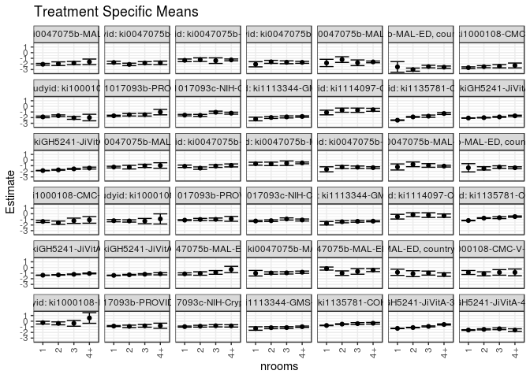

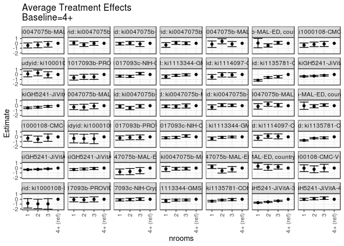

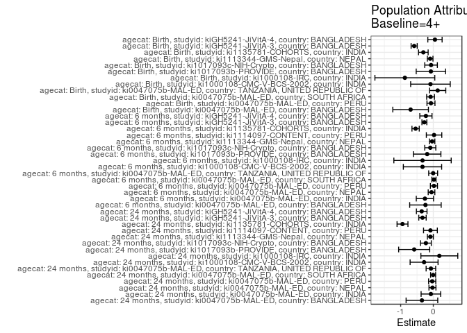

## Results Table

### Parameter: TSM

| agecat | studyid | country | intervention_level | baseline_level | estimate | ci_lower | ci_upper |
| --- | --- | --- | --- | --- | --- | --- | --- |
| Birth | ki0047075b-MAL-ED | BANGLADESH | 4+ | NA | -0.3579455 | -0.9163329 | 0.2004420 |
| Birth | ki0047075b-MAL-ED | BANGLADESH | 1 | NA | -1.1350547 | -1.3168851 | -0.9532243 |
| Birth | ki0047075b-MAL-ED | BANGLADESH | 2 | NA | -1.0727162 | -1.3767885 | -0.7686440 |
| Birth | ki0047075b-MAL-ED | BANGLADESH | 3 | NA | -0.8827783 | -1.2100568 | -0.5554999 |
| Birth | ki0047075b-MAL-ED | PERU | 4+ | NA | -0.8423307 | -1.0416458 | -0.6430156 |
| Birth | ki0047075b-MAL-ED | PERU | 1 | NA | -1.0236287 | -1.5148692 | -0.5323883 |
| Birth | ki0047075b-MAL-ED | PERU | 2 | NA | -0.9803035 | -1.1983209 | -0.7622861 |
| Birth | ki0047075b-MAL-ED | PERU | 3 | NA | -0.9573044 | -1.1647417 | -0.7498671 |
| Birth | ki0047075b-MAL-ED | SOUTH AFRICA | 4+ | NA | -0.4688060 | -0.7283817 | -0.2092303 |
| Birth | ki0047075b-MAL-ED | SOUTH AFRICA | 1 | NA | -0.1980000 | -0.4674799 | 0.0714799 |
| Birth | ki0047075b-MAL-ED | SOUTH AFRICA | 2 | NA | -1.0133333 | -1.4164289 | -0.6102377 |
| Birth | ki0047075b-MAL-ED | SOUTH AFRICA | 3 | NA | -0.7058333 | -1.2016555 | -0.2100111 |
| Birth | ki0047075b-MAL-ED | TANZANIA, UNITED REPUBLIC OF | 4+ | NA | -1.2567347 | -1.5615935 | -0.9518759 |
| Birth | ki0047075b-MAL-ED | TANZANIA, UNITED REPUBLIC OF | 1 | NA | -0.8588889 | -1.4085413 | -0.3092365 |
| Birth | ki0047075b-MAL-ED | TANZANIA, UNITED REPUBLIC OF | 2 | NA | -1.1070968 | -1.6324652 | -0.5817283 |
| Birth | ki0047075b-MAL-ED | TANZANIA, UNITED REPUBLIC OF | 3 | NA | -1.0022581 | -1.3571466 | -0.6473695 |
| Birth | ki1000108-CMC-V-BCS-2002 | INDIA | 4+ | NA | -0.8740000 | -1.4739904 | -0.2740096 |
| Birth | ki1000108-CMC-V-BCS-2002 | INDIA | 1 | NA | -0.8946053 | -1.2459292 | -0.5432813 |
| Birth | ki1000108-CMC-V-BCS-2002 | INDIA | 2 | NA | -1.1229310 | -1.4808250 | -0.7650370 |
| Birth | ki1000108-CMC-V-BCS-2002 | INDIA | 3 | NA | -0.8750000 | -1.3685904 | -0.3814096 |
| Birth | ki1000108-IRC | INDIA | 4+ | NA | 0.5638725 | -0.3772118 | 1.5049568 |
| Birth | ki1000108-IRC | INDIA | 1 | NA | -0.2693006 | -0.5068840 | -0.0317171 |
| Birth | ki1000108-IRC | INDIA | 2 | NA | -0.3884262 | -0.6478353 | -0.1290172 |
| Birth | ki1000108-IRC | INDIA | 3 | NA | -0.3816228 | -0.8927135 | 0.1294680 |
| Birth | ki1017093b-PROVIDE | BANGLADESH | 4+ | NA | -0.8110087 | -1.2693390 | -0.3526783 |
| Birth | ki1017093b-PROVIDE | BANGLADESH | 1 | NA | -0.8729046 | -0.9591143 | -0.7866950 |
| Birth | ki1017093b-PROVIDE | BANGLADESH | 2 | NA | -0.9252872 | -1.1383851 | -0.7121894 |
| Birth | ki1017093b-PROVIDE | BANGLADESH | 3 | NA | -0.8341429 | -1.0754689 | -0.5928170 |
| Birth | ki1017093c-NIH-Crypto | BANGLADESH | 4+ | NA | -0.8405889 | -1.0463663 | -0.6348115 |
| Birth | ki1017093c-NIH-Crypto | BANGLADESH | 1 | NA | -0.9706458 | -1.0697319 | -0.8715598 |

[output cut: 138 more lines]

### Parameter: E(Y)

| agecat | studyid | country | intervention_level | baseline_level | estimate | ci_lower | ci_upper |
| --- | --- | --- | --- | --- | --- | --- | --- |
| Birth | ki0047075b-MAL-ED | BANGLADESH | NA | NA | -1.0530516 | -1.1896058 | -0.9164975 |
| Birth | ki0047075b-MAL-ED | PERU | NA | NA | -0.9141395 | -1.0364098 | -0.7918693 |
| Birth | ki0047075b-MAL-ED | SOUTH AFRICA | NA | NA | -0.5523958 | -0.7550074 | -0.3497843 |
| Birth | ki0047075b-MAL-ED | TANZANIA, UNITED REPUBLIC OF | NA | NA | -1.1225000 | -1.3335666 | -0.9114334 |
| Birth | ki1000108-CMC-V-BCS-2002 | INDIA | NA | NA | -0.9611957 | -1.1776967 | -0.7446946 |
| Birth | ki1000108-IRC | INDIA | NA | NA | -0.3079016 | -0.4694769 | -0.1463262 |
| Birth | ki1017093b-PROVIDE | BANGLADESH | NA | NA | -0.8851020 | -0.9601332 | -0.8100709 |
| Birth | ki1017093c-NIH-Crypto | BANGLADESH | NA | NA | -0.9094945 | -0.9809370 | -0.8380521 |
| Birth | ki1113344-GMS-Nepal | NEPAL | NA | NA | -1.0851580 | -1.1651811 | -1.0051350 |
| Birth | ki1135781-COHORTS | INDIA | NA | NA | -0.6777626 | -0.7107167 | -0.6448086 |
| Birth | kiGH5241-JiVitA-3 | BANGLADESH | NA | NA | -1.1730044 | -1.2010793 | -1.1449294 |
| Birth | kiGH5241-JiVitA-4 | BANGLADESH | NA | NA | -1.5236135 | -1.5727559 | -1.4744711 |
| 6 months | ki0047075b-MAL-ED | BANGLADESH | NA | NA | -1.2031806 | -1.3209873 | -1.0853738 |
| 6 months | ki0047075b-MAL-ED | INDIA | NA | NA | -1.2069078 | -1.3255669 | -1.0882487 |
| 6 months | ki0047075b-MAL-ED | NEPAL | NA | NA | -0.5610593 | -0.6737915 | -0.4483272 |
| 6 months | ki0047075b-MAL-ED | PERU | NA | NA | -1.3293333 | -1.4383829 | -1.2202838 |
| 6 months | ki0047075b-MAL-ED | SOUTH AFRICA | NA | NA | -1.0554016 | -1.1850591 | -0.9257441 |
| 6 months | ki0047075b-MAL-ED | TANZANIA, UNITED REPUBLIC OF | NA | NA | -1.3687449 | -1.4907629 | -1.2467270 |
| 6 months | ki1000108-CMC-V-BCS-2002 | INDIA | NA | NA | -1.4234508 | -1.5645974 | -1.2823042 |
| 6 months | ki1000108-IRC | INDIA | NA | NA | -1.2470123 | -1.3779341 | -1.1160906 |
| 6 months | ki1017093b-PROVIDE | BANGLADESH | NA | NA | -1.0916915 | -1.1661176 | -1.0172654 |
| 6 months | ki1017093c-NIH-Crypto | BANGLADESH | NA | NA | -1.1986783 | -1.2700937 | -1.1272630 |
| 6 months | ki1113344-GMS-Nepal | NEPAL | NA | NA | -1.3508392 | -1.4290633 | -1.2726152 |
| 6 months | ki1114097-CONTENT | PERU | NA | NA | -0.3139217 | -0.4868486 | -0.1409948 |
| 6 months | ki1135781-COHORTS | INDIA | NA | NA | -1.0413281 | -1.0740395 | -1.0086167 |
| 6 months | kiGH5241-JiVitA-3 | BANGLADESH | NA | NA | -1.3357956 | -1.3588816 | -1.3127096 |
| 6 months | kiGH5241-JiVitA-4 | BANGLADESH | NA | NA | -1.3440477 | -1.3813060 | -1.3067894 |
| 24 months | ki0047075b-MAL-ED | BANGLADESH | NA | NA | -1.9789151 | -2.1055330 | -1.8522972 |
| 24 months | ki0047075b-MAL-ED | INDIA | NA | NA | -1.8848458 | -2.0096941 | -1.7599975 |
| 24 months | ki0047075b-MAL-ED | NEPAL | NA | NA | -1.3118640 | -1.4315132 | -1.1922149 |
| 24 months | ki0047075b-MAL-ED | PERU | NA | NA | -1.7544776 | -1.8753255 | -1.6336298 |
| 24 months | ki0047075b-MAL-ED | SOUTH AFRICA | NA | NA | -1.6491807 | -1.7842885 | -1.5140729 |
| 24 months | ki0047075b-MAL-ED | TANZANIA, UNITED REPUBLIC OF | NA | NA | -2.6451636 | -2.7802323 | -2.5100948 |
| 24 months | ki1000108-CMC-V-BCS-2002 | INDIA | NA | NA | -2.5588679 | -2.6583730 | -2.4593629 |
| 24 months | ki1000108-IRC | INDIA | NA | NA | -1.8014906 | -1.8952579 | -1.7077232 |
| 24 months | ki1017093b-PROVIDE | BANGLADESH | NA | NA | -1.6024221 | -1.6857420 | -1.5191023 |
| 24 months | ki1017093c-NIH-Crypto | BANGLADESH | NA | NA | -1.4412646 | -1.5249156 | -1.3576135 |
| 24 months | ki1113344-GMS-Nepal | NEPAL | NA | NA | -1.8874180 | -1.9728588 | -1.8019773 |
| 24 months | ki1114097-CONTENT | PERU | NA | NA | -0.6962195 | -0.8674103 | -0.5250287 |
| 24 months | ki1135781-COHORTS | INDIA | NA | NA | -2.2131714 | -2.2523749 | -2.1739679 |
| 24 months | kiGH5241-JiVitA-3 | BANGLADESH | NA | NA | -2.0196832 | -2.0473250 | -1.9920413 |
| 24 months | kiGH5241-JiVitA-4 | BANGLADESH | NA | NA | -1.7803708 | -1.8158650 | -1.7448765 |

### Parameter: ATE

| agecat | studyid | country | intervention_level | baseline_level | estimate | ci_lower | ci_upper |
| --- | --- | --- | --- | --- | --- | --- | --- |
| Birth | ki0047075b-MAL-ED | BANGLADESH | 4+ | 4+ | 0.0000000 | 0.0000000 | 0.0000000 |
| Birth | ki0047075b-MAL-ED | BANGLADESH | 1 | 4+ | -0.7771092 | -1.3651487 | -0.1890697 |
| Birth | ki0047075b-MAL-ED | BANGLADESH | 2 | 4+ | -0.7147708 | -1.3512814 | -0.0782602 |
| Birth | ki0047075b-MAL-ED | BANGLADESH | 3 | 4+ | -0.5248329 | -1.1719422 | 0.1222764 |
| Birth | ki0047075b-MAL-ED | PERU | 4+ | 4+ | 0.0000000 | 0.0000000 | 0.0000000 |
| Birth | ki0047075b-MAL-ED | PERU | 1 | 4+ | -0.1812980 | -0.7104387 | 0.3478426 |
| Birth | ki0047075b-MAL-ED | PERU | 2 | 4+ | -0.1379728 | -0.4343734 | 0.1584278 |
| Birth | ki0047075b-MAL-ED | PERU | 3 | 4+ | -0.1149737 | -0.4001883 | 0.1702408 |
| Birth | ki0047075b-MAL-ED | SOUTH AFRICA | 4+ | 4+ | 0.0000000 | 0.0000000 | 0.0000000 |
| Birth | ki0047075b-MAL-ED | SOUTH AFRICA | 1 | 4+ | 0.2708060 | -0.1033584 | 0.6449703 |
| Birth | ki0047075b-MAL-ED | SOUTH AFRICA | 2 | 4+ | -0.5445274 | -1.0239704 | -0.0650843 |
| Birth | ki0047075b-MAL-ED | SOUTH AFRICA | 3 | 4+ | -0.2370274 | -0.7966873 | 0.3226325 |
| Birth | ki0047075b-MAL-ED | TANZANIA, UNITED REPUBLIC OF | 4+ | 4+ | 0.0000000 | 0.0000000 | 0.0000000 |
| Birth | ki0047075b-MAL-ED | TANZANIA, UNITED REPUBLIC OF | 1 | 4+ | 0.3978458 | -0.2306895 | 1.0263811 |
| Birth | ki0047075b-MAL-ED | TANZANIA, UNITED REPUBLIC OF | 2 | 4+ | 0.1496379 | -0.4577754 | 0.7570512 |
| Birth | ki0047075b-MAL-ED | TANZANIA, UNITED REPUBLIC OF | 3 | 4+ | 0.2544766 | -0.2133746 | 0.7223279 |
| Birth | ki1000108-CMC-V-BCS-2002 | INDIA | 4+ | 4+ | 0.0000000 | 0.0000000 | 0.0000000 |
| Birth | ki1000108-CMC-V-BCS-2002 | INDIA | 1 | 4+ | -0.0206053 | -0.7158872 | 0.6746767 |
| Birth | ki1000108-CMC-V-BCS-2002 | INDIA | 2 | 4+ | -0.2489310 | -0.9475558 | 0.4496938 |
| Birth | ki1000108-CMC-V-BCS-2002 | INDIA | 3 | 4+ | -0.0010000 | -0.7779299 | 0.7759299 |
| Birth | ki1000108-IRC | INDIA | 4+ | 4+ | 0.0000000 | 0.0000000 | 0.0000000 |
| Birth | ki1000108-IRC | INDIA | 1 | 4+ | -0.8331731 | -1.8041660 | 0.1378198 |
| Birth | ki1000108-IRC | INDIA | 2 | 4+ | -0.9522988 | -1.9296203 | 0.0250228 |
| Birth | ki1000108-IRC | INDIA | 3 | 4+ | -0.9454953 | -2.0229095 | 0.1319189 |
| Birth | ki1017093b-PROVIDE | BANGLADESH | 4+ | 4+ | 0.0000000 | 0.0000000 | 0.0000000 |
| Birth | ki1017093b-PROVIDE | BANGLADESH | 1 | 4+ | -0.0618960 | -0.5292094 | 0.4054175 |
| Birth | ki1017093b-PROVIDE | BANGLADESH | 2 | 4+ | -0.1142786 | -0.6216765 | 0.3931193 |
| Birth | ki1017093b-PROVIDE | BANGLADESH | 3 | 4+ | -0.0231343 | -0.5427950 | 0.4965265 |
| Birth | ki1017093c-NIH-Crypto | BANGLADESH | 4+ | 4+ | 0.0000000 | 0.0000000 | 0.0000000 |
| Birth | ki1017093c-NIH-Crypto | BANGLADESH | 1 | 4+ | -0.1300569 | -0.3586239 | 0.0985100 |

[output cut: 138 more lines]

### Parameter: PAR

| agecat | studyid | country | intervention_level | baseline_level | estimate | ci_lower | ci_upper |
| --- | --- | --- | --- | --- | --- | --- | --- |
| Birth | ki0047075b-MAL-ED | BANGLADESH | 4+ | NA | -0.6951062 | -1.2404835 | -0.1497288 |
| Birth | ki0047075b-MAL-ED | PERU | 4+ | NA | -0.0718088 | -0.1942535 | 0.0506358 |
| Birth | ki0047075b-MAL-ED | SOUTH AFRICA | 4+ | NA | -0.0835899 | -0.2035080 | 0.0363283 |
| Birth | ki0047075b-MAL-ED | TANZANIA, UNITED REPUBLIC OF | 4+ | NA | 0.1342347 | -0.1139344 | 0.3824038 |
| Birth | ki1000108-CMC-V-BCS-2002 | INDIA | 4+ | NA | -0.0871957 | -0.6936048 | 0.5192134 |
| Birth | ki1000108-IRC | INDIA | 4+ | NA | -0.8717741 | -1.7888857 | 0.0453375 |
| Birth | ki1017093b-PROVIDE | BANGLADESH | 4+ | NA | -0.0740934 | -0.5242858 | 0.3760990 |
| Birth | ki1017093c-NIH-Crypto | BANGLADESH | 4+ | NA | -0.0689057 | -0.2616437 | 0.1238324 |
| Birth | ki1113344-GMS-Nepal | NEPAL | 4+ | NA | -0.0966696 | -0.1825161 | -0.0108231 |
| Birth | ki1135781-COHORTS | INDIA | 4+ | NA | -0.3056393 | -0.4527891 | -0.1584894 |
| Birth | kiGH5241-JiVitA-3 | BANGLADESH | 4+ | NA | -0.5863348 | -0.6800964 | -0.4925732 |
| Birth | kiGH5241-JiVitA-4 | BANGLADESH | 4+ | NA | 0.0507761 | -0.1680386 | 0.2695907 |
| 6 months | ki0047075b-MAL-ED | BANGLADESH | 4+ | NA | -0.2413434 | -0.7238113 | 0.2411244 |
| 6 months | ki0047075b-MAL-ED | INDIA | 4+ | NA | -0.2571573 | -0.5219085 | 0.0075939 |
| 6 months | ki0047075b-MAL-ED | NEPAL | 4+ | NA | -0.0549345 | -0.1566747 | 0.0468057 |
| 6 months | ki0047075b-MAL-ED | PERU | 4+ | NA | 0.0191181 | -0.0890626 | 0.1272988 |
| 6 months | ki0047075b-MAL-ED | SOUTH AFRICA | 4+ | NA | 0.0195509 | -0.0443439 | 0.0834456 |
| 6 months | ki0047075b-MAL-ED | TANZANIA, UNITED REPUBLIC OF | 4+ | NA | -0.0045401 | -0.1411299 | 0.1320496 |
| 6 months | ki1000108-CMC-V-BCS-2002 | INDIA | 4+ | NA | -0.3315041 | -0.9184588 | 0.2554506 |
| 6 months | ki1000108-IRC | INDIA | 4+ | NA | -0.3303226 | -1.2087476 | 0.5481024 |
| 6 months | ki1017093b-PROVIDE | BANGLADESH | 4+ | NA | -0.1882512 | -0.6093429 | 0.2328404 |
| 6 months | ki1017093c-NIH-Crypto | BANGLADESH | 4+ | NA | -0.0927849 | -0.2621680 | 0.0765981 |
| 6 months | ki1113344-GMS-Nepal | NEPAL | 4+ | NA | -0.0355168 | -0.1178774 | 0.0468438 |
| 6 months | ki1114097-CONTENT | PERU | 4+ | NA | 0.0228558 | -0.2137158 | 0.2594273 |
| 6 months | ki1135781-COHORTS | INDIA | 4+ | NA | -0.5426536 | -0.6539357 | -0.4313716 |
| 6 months | kiGH5241-JiVitA-3 | BANGLADESH | 4+ | NA | -0.2735631 | -0.3483945 | -0.1987317 |
| 6 months | kiGH5241-JiVitA-4 | BANGLADESH | 4+ | NA | -0.2267366 | -0.4135485 | -0.0399247 |
| 24 months | ki0047075b-MAL-ED | BANGLADESH | 4+ | NA | -0.3487357 | -0.8338360 | 0.1363646 |
| 24 months | ki0047075b-MAL-ED | INDIA | 4+ | NA | -0.0743000 | -0.3742311 | 0.2256311 |
| 24 months | ki0047075b-MAL-ED | NEPAL | 4+ | NA | -0.0261380 | -0.1331181 | 0.0808420 |
| 24 months | ki0047075b-MAL-ED | PERU | 4+ | NA | -0.0340989 | -0.1439002 | 0.0757024 |
| 24 months | ki0047075b-MAL-ED | SOUTH AFRICA | 4+ | NA | -0.0061059 | -0.0829711 | 0.0707593 |
| 24 months | ki0047075b-MAL-ED | TANZANIA, UNITED REPUBLIC OF | 4+ | NA | -0.0737860 | -0.2202885 | 0.0727165 |
| 24 months | ki1000108-CMC-V-BCS-2002 | INDIA | 4+ | NA | -0.2825857 | -0.7105818 | 0.1454105 |
| 24 months | ki1000108-IRC | INDIA | 4+ | NA | 0.1844131 | -0.3807896 | 0.7496158 |
| 24 months | ki1017093b-PROVIDE | BANGLADESH | 4+ | NA | -0.5858552 | -1.0618069 | -0.1099034 |
| 24 months | ki1017093c-NIH-Crypto | BANGLADESH | 4+ | NA | -0.2272176 | -0.3921832 | -0.0622521 |
| 24 months | ki1113344-GMS-Nepal | NEPAL | 4+ | NA | -0.0905436 | -0.1813186 | 0.0002314 |
| 24 months | ki1114097-CONTENT | PERU | 4+ | NA | -0.0882704 | -0.2996133 | 0.1230724 |
| 24 months | ki1135781-COHORTS | INDIA | 4+ | NA | -0.9440248 | -1.1110706 | -0.7769790 |
| 24 months | kiGH5241-JiVitA-3 | BANGLADESH | 4+ | NA | -0.3317029 | -0.4448318 | -0.2185739 |
| 24 months | kiGH5241-JiVitA-4 | BANGLADESH | 4+ | NA | -0.3552980 | -0.5177167 | -0.1928793 |